# QTM 220 Problem Set 4

Carol Zhou

2023-10-20

```r
library(tidyverse)
```

NBA Draft Data: Sample

```r
nba.sample = read.csv("nba_sample_draft.csv")
```

```r
tapply(nba.sample$net_rating, nba.sample$draftlevel, mean)
```

```
##           1           2           3
##   0.7130435  -3.8230769 -14.4714286
```

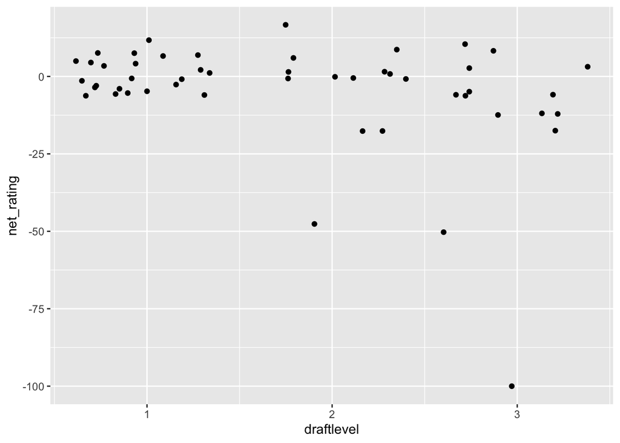

```r
ggplot(nba.sample, aes(draftlevel, net_rating)) +
  geom_jitter()
```

The sub-sample means of net rating among those drafted in the first , second, and undrafted round are 0.71, -3.82, and -14.47 respectively.

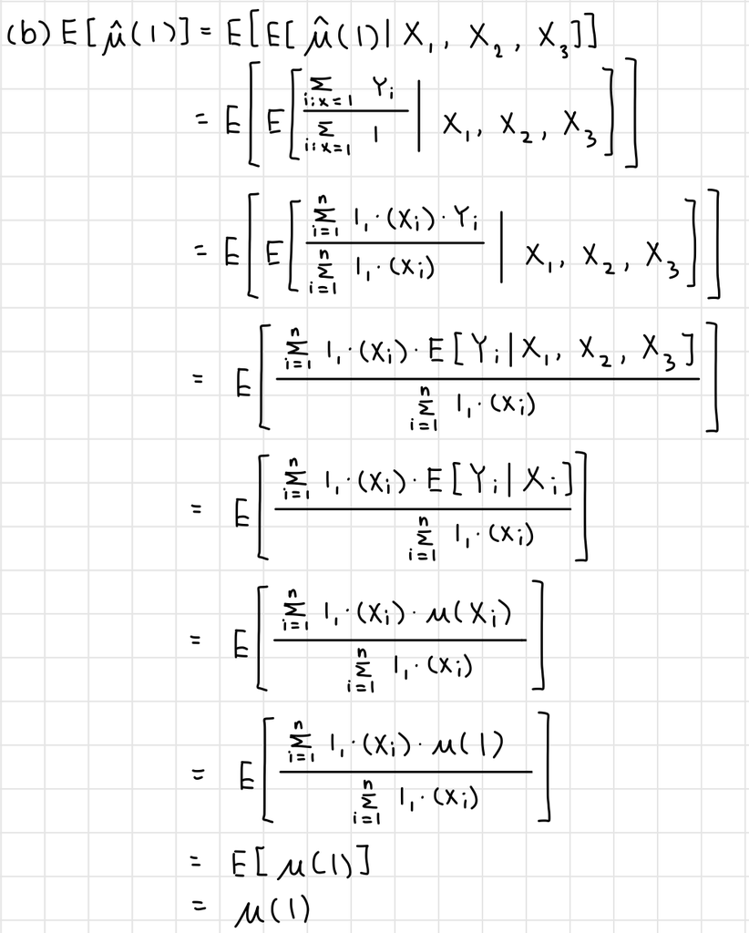

```r
theta = 0
for (i in 2:3) {
  theta = theta + (mean(nba.sample$net_rating[nba.sample$draftlevel==i]) - mean(nba.sample$net_rating[nba.sample$draftlevel==i-1]))
}
theta / 2
```

```
## [1] -7.592236
```

The average incremental difference in mean net rating across the draft levels is -7.59.

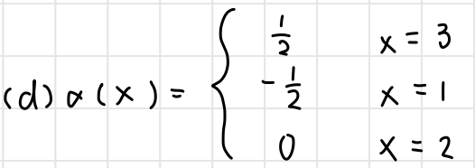

```r
sqrt(((var(nba.sample$net_rating[nba.sample$draftlevel==3]) * (1/2)^2 / sum(nba.sample$draftlevel==3)) + (var(nba.sample$net_rating[nba.sample$draftlevel==1]) * (-1/2)^2 / sum(nba.sample$draftlevel==1))) / 50)
```

```
## [1] 0.5470639
```

The estimated standard error is 0.55.

```r
set.seed(10086)
n_draws = 10000
n_sample = 50
theta.bs = rep(NA, n_draws)
for(i in 1:n_draws) {
    index_bs = sample(1:n_sample, n_sample, T)
    df_bs = nba.sample[index_bs,]
    theta.bs[i] = (1/2)*mean(df_bs$net_rating[df_bs$draftlevel==3]) - (1/2)*mean(df_bs$net_rating[df_bs$draftlevel==1])
}
quantile(theta.bs, c(0.025, 0.975))
```

```
##       2.5%      97.5%
## -16.059256  -1.377682
```

The 95% confidence interval is (-16.06, -1.38).

```r
theta2 = 0
for (i in 2:3) {
  p = sum(nba.sample$draftlevel==i) / sum(nba.sample$draftlevel!=1)
  theta2 = theta2 + (p * (mean(nba.sample$net_rating[nba.sample$draftlevel==i]) - mean(nba.sample$net_rating[nba.sample$draftlevel==i-1])))
}
theta2
```

```
## [1] -7.705425
```

The weighted average incremental difference is -7.71.

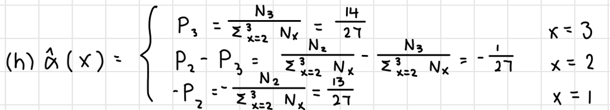

```r
n1 = sum(nba.sample$draftlevel == 1)
n2 = sum(nba.sample$draftlevel == 2)
n3 = sum(nba.sample$draftlevel == 3)
p2 = n2 / sum(nba.sample$draftlevel > 1)
p3 = n3 / sum(nba.sample$draftlevel > 1)
v1 = var(nba.sample$net_rating[nba.sample$draftlevel==1])
v2 = var(nba.sample$net_rating[nba.sample$draftlevel==2])
v3 = var(nba.sample$net_rating[nba.sample$draftlevel==3])
est.std.err = sqrt(((-p2)^2*v1/n1 + (p2-p3)^2*v2/n2 + p3^2*v3/n3) / 50)
est.std.err
```

```
## [1] 0.5670101
```

```r
theta2 - (1.96 * est.std.err)
```

```
## [1] -8.816765
```

The estimated standard error is 0.57. The lower bound on the estimated standard error is -8.82.

```r
theta2.bs = rep(NA, n_draws)
mean_subgroup = tapply(nba.sample$net_rating, nba.sample$draftlevel, mean)
for(i in 1:n_draws){
    index_bs2 = sample(1:n_sample, n_sample, T)
    df_bs2 = nba.sample[index_bs2,]
    p1 = -sum(df_bs2$draftlevel == 2) / sum(df_bs2$draftlevel > 1)
    p2 = sum(df_bs2$draftlevel == 2) / sum(df_bs2$draftlevel > 1) - sum(df_bs2$draftlevel == 3) / sum(df_bs2$draftlevel > 1)
    p3 = sum(df_bs2$draftlevel == 3) / sum(df_bs2$draftlevel > 1)
    theta2.bs[i] = p1*mean_subgroup[1] + p2*mean_subgroup[2] + p3*mean_subgroup[3]
}
quantile(theta2.bs, c(0.025, 0.975))
```

```
##      2.5%     97.5%
## -8.865618 -6.507808
```

The 95% confidence interval is (-8.86, -6.5).

```r
x = nba.sample$draftlevel
x_bar = mean(x)
w_tilde = rep(NA, 3)
denominator = sum((x - x_bar)^2)
for(i in 1:3) {
  w_tilde[i] = sum(x==i)*(i-x_bar) / denominator
}
sum(w_tilde * mean_subgroup)
```

```
## [1] -7.390107
```

The least squares difference in mean net rating is -7.39.

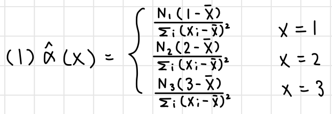

```r
subgroup.var = rep(NA, 3)
for(i in 1:3) {
  subgroup.var[i] = var(nba.sample$net_rating[nba.sample$draftlevel==i])
}
N.x = rep(NA, 3)
for(i in 1:3) {
  N.x[i] = sum(nba.sample$draftlevel==i)
}
variance = sum(w_tilde^2 * subgroup.var / N.x)
est.std.err = sqrt(variance / 50)
est.std.err
```

```
## [1] 0.5141443
```

```r
sum(w_tilde * mean_subgroup) - (1.96 * est.std.err)
```

```
## [1] -8.39783
```

```r
theta3.bs = rep(NA, n_draws)
w_tilde_bs = rep(NA, 3)
for(i in 1:n_draws) {
    index_bs3 = sample(1:n_sample, n_sample, T)
    df_bs3 = nba.sample[index_bs3,]
    for(j in 1:3){
        x.bar = mean(df_bs3$draftlevel)
        s_squared = var(df_bs3$draftlevel)
        n_df = nrow(df_bs3) - 1
        w_tilde_bs[j] = sum(df_bs3$draftlevel == j) * (j-x.bar) / (s_squared*n_df)
    }
    theta3.bs[i] = sum(w_tilde_bs * mean_subgroup)
}
quantile(theta3.bs, c(0.025, 0.975))
```

```
##      2.5%     97.5%
## -7.649899 -6.965171
```

The 95% confidence interval is (-7.65, -6.96).

```r
table(nba.sample$draftlevel)
```

```
##
##  1  2  3
## 23 13 14
```

```r
tapply(nba.sample$net_rating, nba.sample$draftlevel, mean)
```

```
##           1           2           3
##   0.7130435  -3.8230769 -14.4714286
```

```r
tapply(nba.sample$net_rating, nba.sample$draftlevel, var)
```

```
##         1         2         3
##  27.99482 257.69859 820.94066
```

```r
# avg. increment
var(nba.sample$net_rating[nba.sample$draftlevel==1]) * (-1/2)^2 / sum(nba.sample$draftlevel==1)
```

```
## [1] 0.3042915
```

```r
var(nba.sample$net_rating[nba.sample$draftlevel==3]) * (1/2)^2 / sum(nba.sample$draftlevel==3)
```

```
## [1] 14.65965
```

```r
# weighted increment
-p2
```

```
## [1] 0.2307692
```

```r
p2-p3
```

```
## [1] -0.8461538
```

```r
p3
```

```
## [1] 0.6153846
```

```r
(-p2)^2
```

```
## [1] 0.05325444
```

```r
(p2-p3)^2
```

```
## [1] 0.7159763
```

```r
(p3)^2
```

```
## [1] 0.3786982
```

```r
var(nba.sample$net_rating[nba.sample$draftlevel==1]) * (-p)^2 / sum(nba.sample$draftlevel==1)
```

```
## [1] 0.3272491
```

```r
var(nba.sample$net_rating[nba.sample$draftlevel==2]) * (p2-p3)^2 / sum(nba.sample$draftlevel==2)
```

```
## [1] 14.19278
```

```r
var(nba.sample$net_rating[nba.sample$draftlevel==3]) * (p3)^2 / sum(nba.sample$draftlevel==3)
```

```
## [1] 22.20634
```

```r
# least squares
w_tilde
```

```
## [1] -0.53306953  0.06613906  0.46693047
```

```r
w_tilde^2
```

```
## [1] 0.284163125 0.004374375 0.218024063
```

```r
for(i in 1:3) {
  result = var(nba.sample$net_rating[nba.sample$draftlevel==i]) * (w_tilde[i])^2 / sum(nba.sample$draftlevel==i)
  print(result)
}
```

```
## [1] 0.3458737
## [1] 0.08671311
## [1] 12.78463
```

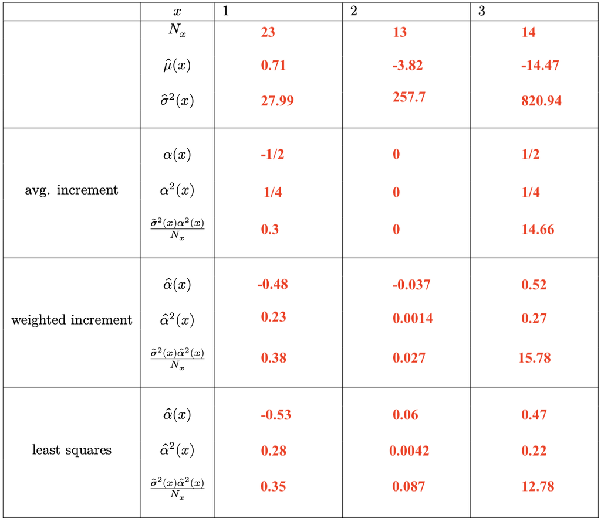

Population Data

```r
nba.pop = read.csv("nba_population.csv")
```

```r
tapply(nba.pop$net_rating, nba.pop$draftlevel, mean)
```

```
##         1         2         3
## -1.427957 -7.072917 -5.455495
```

```r
table(nba.pop$draftlevel)
```

```
##
##   1   2   3
## 279 144 182
```

```r
tapply(nba.pop$net_rating, nba.pop$draftlevel, var)
```

```
##        1        2        3
## 337.0016 315.3823 693.7344
```

The sub-population means of net rating among those drafted in the first , second, and undrafted round are -1.42, -7.07, and -5.46 respectively. Compare to the sub-sample means, the sub-population means of the first round is negative, the second round is lower, and the undraft round is higher. There are 279, 144, and 182 players in the first, second, and undrafted round respectively. The sub-population variances in the first, second, and undrafted round are 337, 315.38, and 693.73 respectively.

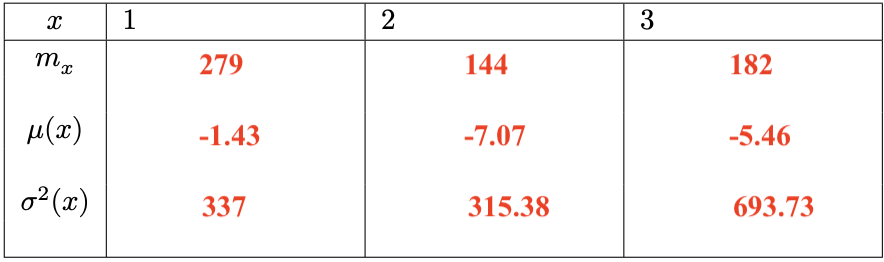

```r
theta.pop = 0
for (i in 2:3) {
  theta.pop = theta.pop + (mean(nba.pop$net_rating[nba.pop$draftlevel==i]) - mean(nba.pop$net_rating[nba.pop$draftlevel==i-1]))
}
theta.pop / 2
```

```
## [1] -2.013769
```

The average incremental difference in mean net rating across the draft levels in the population is -2.01. Compare to my estimate, which is -7.59, the population difference is higher.

```r
n_draws = 10000
n_sample = 605
theta.pop.sam = rep(NA, n_draws)
for(i in 1:n_draws){
    index_bs = sample(1:n_sample, n_sample, T)
    df_bs = nba.pop[index_bs,]
    theta.pop.sam[i] = (1/2)*mean(df_bs$net_rating[df_bs$draftlevel==3]) - (1/2)*mean(df_bs$net_rating[df_bs$draftlevel==1])
}
sd(theta.pop.sam, na.rm = T) / sqrt(605)
```

```
## [1] 0.04515518
```

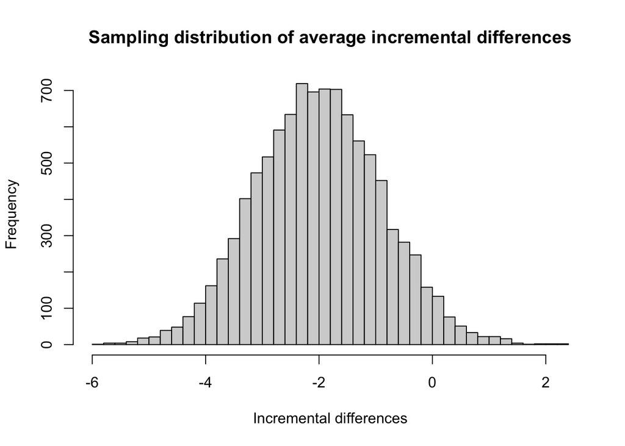

```r
hist(theta.pop.sam, breaks = 50, main = "Sampling distribution of average incremental differences", xlab = "Incremental differences")
```

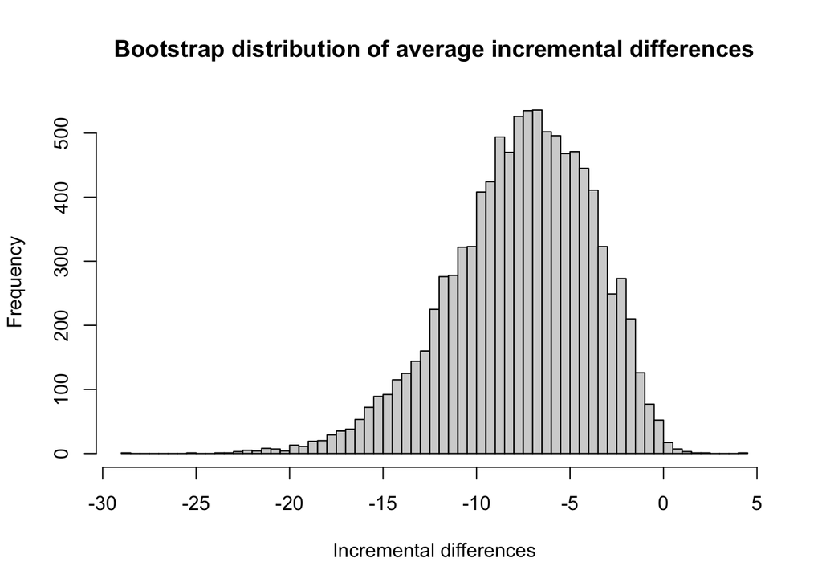

```r
hist(theta.bs, breaks = 50, main = "Bootstrap distribution of average incremental differences", xlab = "Incremental differences")
```

The size (n) of the repeated samples from the population should be 605. The standard error for this estimator is 0.05. This distribution is normal and centers around -2, while the bootstrap estimated sampling distribution is left-skewed and centers around -7. The spread of the sampling distribution is smaller than the bootstrap estimated sampling distribution.

```r
theta2.pop = 0
for (i in 2:3) {
  p = sum(nba.pop$draftlevel==i) / sum(nba.pop$draftlevel!=1)
  theta2.pop = theta2.pop + (p * (mean(nba.pop$net_rating[nba.pop$draftlevel==i]) - mean(nba.pop$net_rating[nba.pop$draftlevel==i-1])))
}
theta2.pop
```

```
## [1] -1.590501
```

The average incremental difference in mean net rating is -1.59. Compare to the estimate, which is -7.71, this difference is higher.

```r
theta2.pop.sam = rep(NA, n_draws)
mean_subgroup = tapply(nba.pop$net_rating, nba.pop$draftlevel, mean)
for(i in 1:n_draws){
    index_bs2 = sample(1:n_sample, n_sample, T)
    df_bs2 = nba.pop[index_bs2,]
    p1 = -sum(df_bs2$draftlevel == 2) / sum(df_bs2$draftlevel > 1)
    p2 = sum(df_bs2$draftlevel == 2) / sum(df_bs2$draftlevel > 1) - sum(df_bs2$draftlevel == 3) / sum(df_bs2$draftlevel > 1)
    p3 = sum(df_bs2$draftlevel == 3) / sum(df_bs2$draftlevel > 1)
    theta2.pop.sam[i] = p1*mean_subgroup[1] + p2*mean_subgroup[2] + p3*mean_subgroup[3]
}
sd(theta2.pop.sam, na.rm = T) / sqrt(605)
```

```
## [1] 0.00815357
```

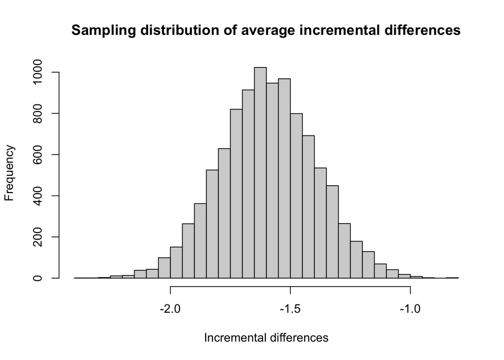

```r
hist(theta2.pop.sam, breaks = 50, main = "Sampling distribution of average incremental differences", xlab = "Incremental differences")
```

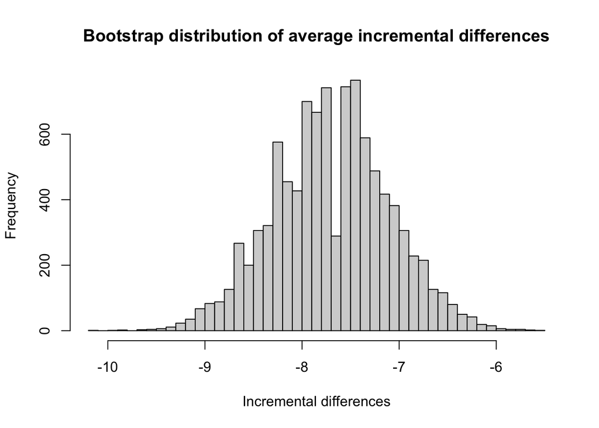

```r
hist(theta2.bs, breaks = 50, main = "Bootstrap distribution of average incremental differences", xlab = "Incremental differences")
```

The size (n) of the repeated samples from the population should be 605. The standard error for this estimator is 0.008. Both distributions are normal. However, this distribution centers around -1.6, while the bootstrap estimated sampling distribution centers around -7.7. The spread of the sampling distribution is smaller than the bootstrap estimated sampling distribution.

```r
x = nba.pop$draftlevel
x_bar = mean(x)
w_tilde = rep(NA, 3)
denominator = sum((x - x_bar)^2)
for(i in 1:3) {
  w_tilde[i] = sum(x==i)*(i-x_bar) / denominator
}
sum(w_tilde * mean_subgroup)
```

```
## [1] -2.201974
```

The least squares difference in mean net rating is -2.2. Compare to the estimate, which is -7.39, this difference is higher.

```r
theta3.pop.sam = rep(NA, n_draws)
w_tilde_bs = rep(NA, 3)
for(i in 1:n_draws) {
    index_bs3 = sample(1:n_sample, n_sample, T)
    df_bs3 = nba.pop[index_bs3,]
    for(j in 1:3){
        x.bar = mean(df_bs3$draftlevel)
        s_squared = var(df_bs3$draftlevel)
        n_df = nrow(df_bs3) - 1
        w_tilde_bs[j] = sum(df_bs3$draftlevel == j) * (j-x.bar) / (s_squared*n_df)
    }
    theta3.pop.sam[i] = sum(w_tilde_bs * mean_subgroup)
}
sd(theta3.pop.sam, na.rm = T) / sqrt(605)
```

```
## [1] 0.001872578
```

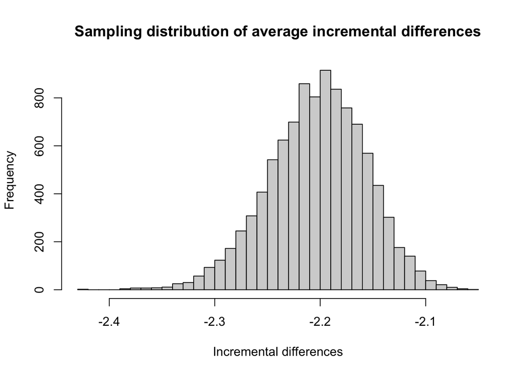

```r
hist(theta3.pop.sam, breaks = 50, main = "Sampling distribution of average incremental differences", xlab = "Incremental differences")
```

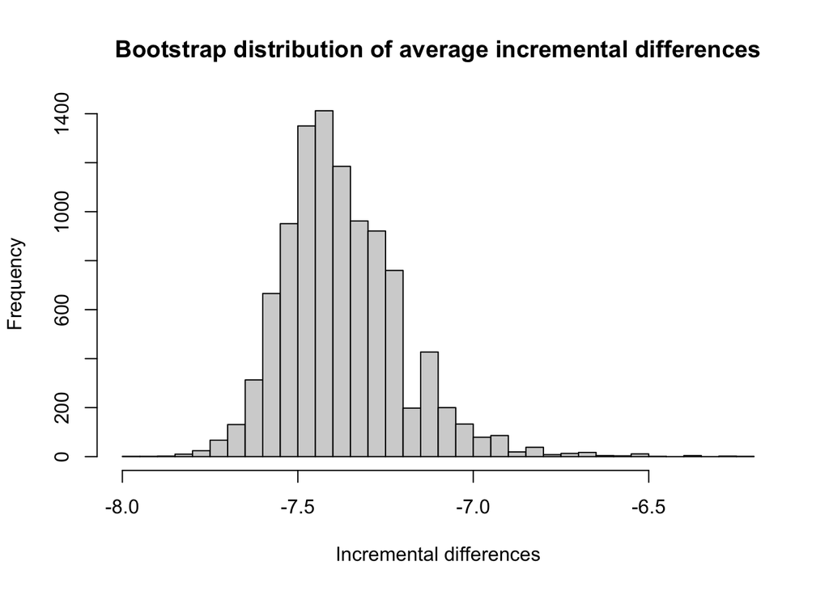

```r
hist(theta3.bs, breaks = 50, main = "Bootstrap distribution of average incremental differences", xlab = "Incremental differences")
```

The size (n) of the repeated samples from the population should be 605. The standard error for this estimator is 0.0018. This distribution is slightly left-skewed and centers around -2.2, while the bootstrap estimated sampling distribution is slightly right-skewed and centers around -7.4. The spread of the sampling distribution is smaller than the bootstrap estimated sampling distribution.

8. Overall, the estimates are lower than the population. The estimated standard errors are not similar to and greater than the standard errors of estimators. The estimators have different standard errors because the sample may not be representative of the population.